# MID

Zirui Zhang

2023-10-25

```r
library(tidyverse)
library(ggplot2)
library(patchwork)
library(nlme)
library(lme4)
library(knitr)
```

```r
load("~/Documents/2023Fall/P8157/P8157/Six Cities.RData")
data = topeka |>  group_by(id) |> filter(n() >= 5) |> ungroup()
length(unique(data$id))
```

```
## [1] 196
```

```r
data = data |>
  mutate(y = exp(log.FEV1)/(height^2),
         age.2 = age^2,
         age.3 = age^3)
```

## Question (a)

Produce a figure of the response, Yki as a function of age. On the figure indicate the individual trajectories for a random sample of 4 girls.

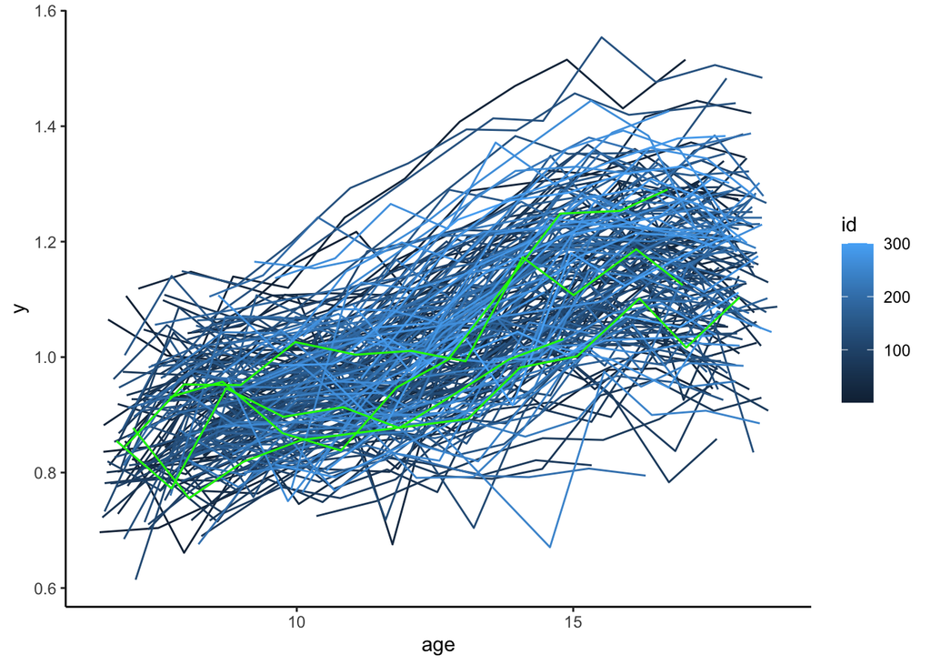

```r
set.seed(200324)
sample = data  |>
  filter(id %in% sample(unique(data$id), 4))

ggplot(data, aes(x = age, y = y, group = id, color = id)) +
  geom_line() +
  geom_line(data = sample, color = "green") +
  theme_classic()
```

## Question (b)

```r
# 1 naivee
fit1.ML = glm(y ~ age + age.2 + age.3, data, family=gaussian)

# 2 randon intercept + independent error
fit2.ML = lme(fixed=y ~ age + age.2 + age.3, random=reStruct(~ 1 | id), data, method="ML")

# 3 random intercept/slope + independent error
fit3.ML = lme(fixed=y ~ age + age.2 + age.3, random=reStruct(~ age | id, pdClass="pdDiag"), data, method="ML")

# 4. random intercept + auto_regressive error
fit4.ML = lme(fixed=y ~ age + age.2 + age.3, random=reStruct(~ 1 | id), correlation=corAR1(form= ~ age| id), data, method="ML")

# 5 random intercept + exponential spatial error
fit5.ML = lme(fixed=y ~ age + age.2 + age.3, random=reStruct(~ 1 | id), correlation=corExp(form= ~ age| id), data, method="ML")

# 6 random intercept + exponential spatial error + independent homo error
fit6.ML = lme(fixed=y ~ age + age.2 + age.3, random=reStruct(~ 1 | id), correlation=corExp(form= ~ age| id, nugget=TRUE), data, method="ML")

# 7 random intercept + independent hetero error
data_cat = data |>
  dplyr::mutate(age.cat = floor(age/2))
fit7.ML = lme(fixed=y ~ age + age.2 + age.3, random=reStruct(~ 1 | id), weights=varIdent(form= ~1 | age.cat), data_cat, method="ML")

# 8 random intercept/slope + independent hetero error
fit8.ML = lme(fixed=y ~ age + age.2 + age.3, random=reStruct(~ age | id), weights=varIdent(form= ~1 | age.cat), data_cat, method="ML")
```

```r
sum = (data.frame(
  logLik = c(logLik(fit1.ML), logLik(fit2.ML), logLik(fit3.ML),logLik(fit4.ML),
             logLik(fit5.ML), logLik(fit6.ML), logLik(fit7.ML), logLik(fit8.ML)),
  AIC = c(AIC(fit1.ML),AIC(fit2.ML),AIC(fit3.ML),AIC(fit4.ML),
          AIC(fit5.ML),AIC(fit6.ML),AIC(fit7.ML),AIC(fit8.ML))
))

colnames(sum) = c("log-Like", "AIC")
rownames(sum) = c("0. Independence", "1. Random intercept + inde. errors",
                  "2. Random intercept/slope + inde. errors", "3. Random intercept + AR errors",
                  "4. Random intercept + ES errors", "5. Random intercept + ES with a 'nugget'",
                  "6. Random intercept + heteroske inde. errors",
                  "7. Random intercept/slope + heteroske inde. errors")
kable(sum, format = "markdown")
```

|  | log-Like | AIC |
| --- | --- | --- |
| 0. Independence | 1291.696 | -2573.393 |
| 1. Random intercept + inde. errors | 2073.425 | -4134.850 |
| 2. Random intercept/slope + inde. errors | 2138.977 | -4263.954 |
| 3. Random intercept + AR errors | 2156.186 | -4298.373 |
| 4. Random intercept + ES errors | 2168.018 | -4322.035 |
| 5. Random intercept + ES with a ‘nugget’ | 2175.572 | -4335.145 |
| 6. Random intercept + heteroske inde. errors | 2092.402 | -4160.803 |
| 7. Random intercept/slope + heteroske inde. errors | 2162.089 | -4296.178 |

Model 4 and 5 give the largest loglikelihood and lowest AIC, provide best fits of the data.

Model 4: $Y_{ki} = \beta_0 + \beta_1\cdot Age_{ki} + \beta_2\cdot Age_{ki}^2+ \beta_3\cdot Age_{ki}^3 + \gamma_{0k} + W_k(T_{ki})+\epsilon_{ki}^*$

$Cov[W_k(T_{ki}), W_k(T_{kj})] = \sigma_W^2exp\{-U_{k,ij}/range\}$

where

$U_{k,ij} = |T_{ki}-T_{kj}|$

Model 5: $Y_{ki} = \beta_0 + \beta_1\cdot Age_{ki} + \beta_2\cdot Age_{ki}^2+ \beta_3\cdot Age_{ki}^3 + \gamma_{0k} + W_k(T_{ki})+\epsilon_{ki}^*$

$Cov[W_k(T_{ki}), W_k(T_{kj})] = \sigma_W^2 (1-n) exp\{-U_{k,ij}/range\}$

where

$U_{k,ij} = |T_{ki}-T_{kj}|$ and $n$ denote the nugget effect.

```r
coef = t((data.frame(
  fit5 = c(summary(fit5.ML)$coefficients$fixed, sqrt(diag(summary(fit5.ML)$varFix))),
  fit6  = c(summary(fit6.ML)$coefficients$fixed, sqrt(diag(summary(fit6.ML)$varFix)))
)))
rownames(coef) = c("Model.4", "Model.5")
colnames(coef) = c("b0", "b1", "b2", "b3",
                   "sd(b0)", "sd(b1)", "sd(b2)", "sd(b3)")
kable(coef, format = "markdown")
```

|  | b0 | b1 | b2 | b3 | sd(b0) | sd(b1) | sd(b2) | sd(b3) |
| --- | --- | --- | --- | --- | --- | --- | --- | --- |
| Model.4 | 1.400998 | -0.1741504 | 0.0175949 | -0.0004801 | 0.1088313 | 0.0276627 | 0.0022521 | 5.89e-05 |
| Model.5 | 1.434293 | -0.1825535 | 0.0182797 | -0.0004980 | 0.1051375 | 0.0266974 | 0.0021707 | 5.67e-05 |

## Question (c)

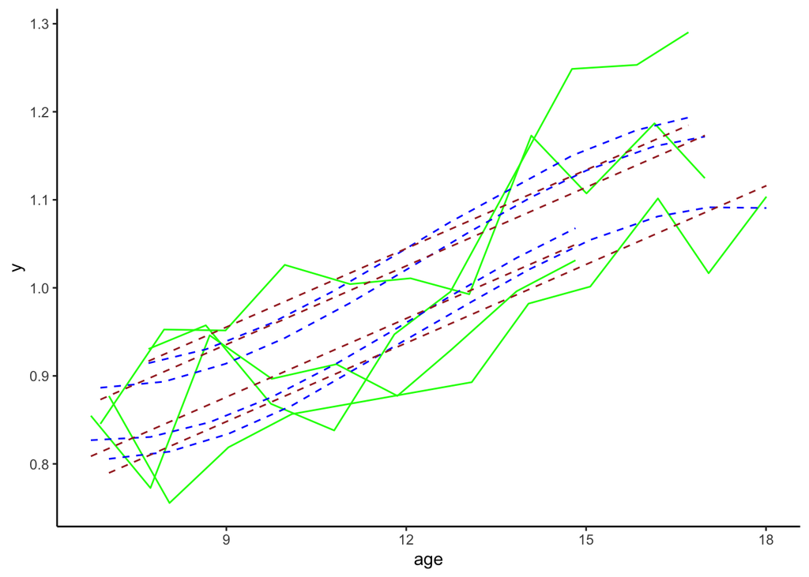

```r
# fit6.ML = lme(fixed=y ~ age + age.2 + age.3, random=reStruct(~ 1 | id), correlation=corExp(form= ~ age| id, nugget=TRUE), data, method="ML")
fit9.ML = lme(fixed=y ~ age, random=reStruct(~ 1 | id), correlation=corExp(form= ~ age| id, nugget=TRUE), data, method="ML")
predict.1 = predict(fit6.ML, sample)
predict.2 = predict(fit9.ML, sample)
ggplot(data, aes(x = age, y = y, group = id, color = id)) +
  geom_line(data = sample, color = "green") +
  geom_line(data = sample, aes(y = predict.1), color = "blue", linetype = "dashed") +
  geom_line(data = sample, aes(y = predict.2), color = "brown", linetype = "dashed") +
  theme_classic()
```

## Question (d)

no inter for coef, fit curve visually

## Question (e)

```r
anova(fit6.ML, fit9.ML)
```

```
##         Model df       AIC       BIC   logLik   Test  L.Ratio p-value
## fit6.ML     1  8 -4335.145 -4291.230 2175.573
## fit9.ML     2  6 -4255.874 -4222.937 2133.937 1 vs 2 83.27109  <.0001
```

I did an ANOVA test on the two models, the p-vlaue was smaller than 0.0001. Thus the null was rejected, suggesting that model(3) with more variables does provide better fit of the data.

## Question (f)

complexity of the model…